# Notes on Chapter 26 - Iteration

The Caveman Coder

2025-08-16

This chapter introduces the concept of **functional programming**.

### Prerequisites

```r
library(tidyverse)
```

Situation: We are tasked to count the number of observations and compute the median in the tibble below:

```r
df <- tibble(
  a = rnorm(10),
  b = rnorm(10),
  c = rnorm(10),
  d = rnorm(10)
)
```

This can be solved using copy-paste:

```r
df |> summarize(
  n = n(),
  a = median(a),
  b = median(b),
  c = median(c),
  d = median(d)
)
```

```
## # A tibble: 1 × 5
##       n      a      b     c      d
##   <int>  <dbl>  <dbl> <dbl>  <dbl>
## 1    10 0.0337 -0.495 0.519 -0.137
```

This breaks the rule of never copy-pasting more than twice, and is prone to mistakes.

Using `across()` to solve the problem above:

```r
df |> summarize(
  n = n(),
  across(a:d, median)
)
```

```
## # A tibble: 1 × 5
##       n      a      b     c      d
##   <int>  <dbl>  <dbl> <dbl>  <dbl>
## 1    10 0.0337 -0.495 0.519 -0.137
```

Voila!

### Selecting columnms with `.cols`

- As the first argument to `across()`, `.cols` specifies which columns you want to iterate over.
- The second argument `.fns`specifies what to do with each column.

Example using `across()` with `everything()`:

```r
df <- tibble(
  grp = sample(2, 10, replace = TRUE),
  a = rnorm(10),
  b = rnorm(10),
  c = rnorm(10),
  d = rnorm(10)
)

df |>
  group_by(grp) |>
  summarize(across(everything(), median))
```

```
## # A tibble: 2 × 5
##     grp      a      b       c      d
##   <int>  <dbl>  <dbl>   <dbl>  <dbl>
## 1     1 -0.848 -0.133  0.1000  0.718
## 2     2  0.980 -0.248 -0.0384 -0.850
```

`where()` allows the user to select columns based on type:

- `where(is.numeric)` selects numeric columns.
- `where(is.character)` selects all string columns.
- `where(is.Date)` selects all date columns.
- `where(is.POSIXct)` selects all date-time columns.
- `where(is.logical)` selects all logical columns.

### Calling a single function

Remember, do not put `()` after the function that you are passing to `across()`. The code below will throw and error:

```r
df |>
  group_by(grp) |>
  summarize(across(everything(), median()))
```

What if we want to pass an argument to the function we are passing to `across()`? For example, the argument `na.rm = TRUE` on `median()`.

Solution: instead of calling the target function directly, we create a new function that calls our target function.

Example:

```r
rnorm_na <- function(n, n_na, mean = 0, sd = 1) {
  sample(c(rnorm(n - n_na, mean = mean, sd = sd), rep(NA, n_na)))
}

df_miss <- tibble(
  a = rnorm_na(5, 1),
  b = rnorm_na(5, 1),
  c = rnorm_na(5, 2),
  d = rnorm(5)
)

# This is the solution
df_miss |>
  summarize(
    across(a:d, function(x) median(x, na.rm = TRUE)),
    n = n()
  )
```

```
## # A tibble: 1 × 5
##        a      b      c     d     n
##    <dbl>  <dbl>  <dbl> <dbl> <int>
## 1 0.0125 -0.462 -0.664 0.301     5
```

There is shorcut for this “throwaway” function: the `\`. Just replace the word `function` with `\`.

Example of handling the anoymous or throwaway function using `\`:

```r
df_miss |>
  summarize(
    across(a:d, \(x) median(x, na.rm = TRUE)),
    n = n()
  )
```

```
## # A tibble: 1 × 5
##        a      b      c     d     n
##    <dbl>  <dbl>  <dbl> <dbl> <int>
## 1 0.0125 -0.462 -0.664 0.301     5
```

How to know how many values were removed when we specified `na.rm = TRUE`? By supplying another function to `across()`:

```r
df_miss |>
  summarize(
    across(a:d, list(
      median = \(x) median(x, na.rm = TRUE),
      n_miss = \(x) sum(is.na(x))
    )),
    n = n()
  )
```

```
## # A tibble: 1 × 9
##   a_median a_n_miss b_median b_n_miss c_median c_n_miss d_median d_n_miss     n
##      <dbl>    <int>    <dbl>    <int>    <dbl>    <int>    <dbl>    <int> <int>
## 1   0.0125        1   -0.462        1   -0.664        2    0.301        0     5
```

### Column names

Specifying what to name the results using the `.names` argument:

```r
df_miss |>
  summarize(
    across(
      a:d,
      list(
        median = \(x) median(x, na.rm = TRUE),
        n_miss = \(x) sum(is.na(x))
      ),
      .names = "{.fn}_{.col}"
    ),
    n = n()
  )
```

```
## # A tibble: 1 × 9
##   median_a n_miss_a median_b n_miss_b median_c n_miss_c median_d n_miss_d     n
##      <dbl>    <int>    <dbl>    <int>    <dbl>    <int>    <dbl>    <int> <int>
## 1   0.0125        1   -0.462        1   -0.664        2    0.301        0     5
```

When using `across()` with `mutate()`, the default action is for `across()` to use the same names as inputs. This means that if you don’t use the `.names` argument, the original values of the columns will be replaced.

Example using `coalesce()` to replace `NA`s with `0`:

```r
df_miss |>
  mutate(
    across(a:d, \(x) coalesce(x, 0))
  )
```

```
## # A tibble: 5 × 4
##        a      b       c      d
##    <dbl>  <dbl>   <dbl>  <dbl>
## 1  0.593 -1.25  -0.0674 -0.720
## 2 -0.934  0.103  0       0.554
## 3  2.15   0.944 -0.664   1.40
## 4  0      0     -1.69    0.301
## 5 -0.568 -1.03   0      -1.85
```

If this is not your intended action, and would instead prefer to create new columns, we can specify the naming format for the new names using `.names`:

```r
df_miss |>
  mutate(
    across(a:d, \(x) coalesce(x, 0), .names = "{.col}_na_zero")
  )
```

```
## # A tibble: 5 × 8
##        a      b       c      d a_na_zero b_na_zero c_na_zero d_na_zero
##    <dbl>  <dbl>   <dbl>  <dbl>     <dbl>     <dbl>     <dbl>     <dbl>
## 1  0.593 -1.25  -0.0674 -0.720     0.593    -1.25    -0.0674    -0.720
## 2 -0.934  0.103 NA       0.554    -0.934     0.103    0          0.554
## 3  2.15   0.944 -0.664   1.40      2.15      0.944   -0.664      1.40
## 4 NA     NA     -1.69    0.301     0         0       -1.69       0.301
## 5 -0.568 -1.03  NA      -1.85     -0.568    -1.03     0         -1.85
```

### Filtering

For filtering, `if_any()` and `if_all()` are the variants of `across()` provided by dplyr.

Example:

```r
df_miss |> filter(if_any(a:d, is.na))
```

```
## # A tibble: 3 × 4
##        a      b     c      d
##    <dbl>  <dbl> <dbl>  <dbl>
## 1 -0.934  0.103 NA     0.554
## 2 NA     NA     -1.69  0.301
## 3 -0.568 -1.03  NA    -1.85
```

```r
df_miss |> filter(if_all(a:d, is.na))
```

```
## # A tibble: 0 × 4
## # ℹ 4 variables: a <dbl>, b <dbl>, c <dbl>, d <dbl>
```

### `across()` in functions

Date expander from Jacob Scott:

```r
expand_dates <- function(df) {
  df |>
    mutate(
      across(where(is.Date), list(
        year = year,
        month = month,
        dat = mday
      ))
    )
}

df_date <- tibble(
  name = c("Amy", "Bob"),
  date = ymd(c("2009-08-03", "2010-01-16"))
)

df_date |>
  expand_dates()
```

```
## # A tibble: 2 × 5
##   name  date       date_year date_month date_dat
##   <chr> <date>         <dbl>      <dbl>    <int>
## 1 Amy   2009-08-03      2009          8        3
## 2 Bob   2010-01-16      2010          1       16
```

Example computing the means of numeric columns:

```r
summarize_means <- function(df, summary_vars = where(is.numeric)) {
  df |>
    summarize(
      across({{ summary_vars }}, \(x) mean(x, na.rm = TRUE)),
      n = n(),
      .groups = "drop"
    )
}

diamonds |>
  group_by(cut) |>
  summarize_means()
```

```
## # A tibble: 5 × 9
##   cut       carat depth table price     x     y     z     n
##   <ord>     <dbl> <dbl> <dbl> <dbl> <dbl> <dbl> <dbl> <int>
## 1 Fair      1.05   64.0  59.1 4359.  6.25  6.18  3.98  1610
## 2 Good      0.849  62.4  58.7 3929.  5.84  5.85  3.64  4906
## 3 Very Good 0.806  61.8  58.0 3982.  5.74  5.77  3.56 12082
## 4 Premium   0.892  61.3  58.7 4584.  5.97  5.94  3.65 13791
## 5 Ideal     0.703  61.7  56.0 3458.  5.51  5.52  3.40 21551
```

```r
diamonds |>
  group_by(cut) |>
  summarize_means(c(carat, x:z))
```

```
## # A tibble: 5 × 6
##   cut       carat     x     y     z     n
##   <ord>     <dbl> <dbl> <dbl> <dbl> <int>
## 1 Fair      1.05   6.25  6.18  3.98  1610
## 2 Good      0.849  5.84  5.85  3.64  4906
## 3 Very Good 0.806  5.74  5.77  3.56 12082
## 4 Premium   0.892  5.97  5.94  3.65 13791
## 5 Ideal     0.703  5.51  5.52  3.40 21551
```

### Compare with `pivot_longer()`

Example of code using `across()` and `summarize()` to do “pivot” operations:

```r
df |>
  summarize(across(a:d, list(median = median, mean = mean)))
```

```
## # A tibble: 1 × 8
##   a_median  a_mean b_median b_mean c_median c_mean d_median d_mean
##      <dbl>   <dbl>    <dbl>  <dbl>    <dbl>  <dbl>    <dbl>  <dbl>
## 1  -0.0498 -0.0221   -0.190 -0.155   0.0308 0.0331   0.0477 -0.206
```

We could compute the same values using `pivot_longer()` and `summarize()`:

```r
long <- df |>
  pivot_longer(a:d) |>
  group_by(name) |>
  summarize(
    median = median(value),
    mean = mean(value)
  )

long
```

```
## # A tibble: 4 × 3
##   name   median    mean
##   <chr>   <dbl>   <dbl>
## 1 a     -0.0498 -0.0221
## 2 b     -0.190  -0.155
## 3 c      0.0308  0.0331
## 4 d      0.0477 -0.206
```

To make the format similar to the first result, we could pivot again:

```r
long |>
  pivot_wider(
    names_from = name,
    values_from = c(median, mean),
    names_vary = "slowest",
    names_glue = "{name}_{.value}"
  )
```

```
## # A tibble: 1 × 8
##   a_median  a_mean b_median b_mean c_median c_mean d_median d_mean
##      <dbl>   <dbl>    <dbl>  <dbl>    <dbl>  <dbl>    <dbl>  <dbl>
## 1  -0.0498 -0.0221   -0.190 -0.155   0.0308 0.0331   0.0477 -0.206
```

Using this technique will enable us to do more complicated operations that is not directly possible with `across()`. For example, consider the data below:

```r
df_paired <- tibble(
  a_val = rnorm(10),
  a_wts = runif(10),
  b_val = rnorm(10),
  b_wts = runif(10),
  c_val = rnorm(10),
  c_wts = runif(10),
  d_val = rnorm(10),
  d_wts = runif(10)
)

df_paired
```

```
## # A tibble: 10 × 8
##       a_val a_wts   b_val b_wts   c_val  c_wts  d_val d_wts
##       <dbl> <dbl>   <dbl> <dbl>   <dbl>  <dbl>  <dbl> <dbl>
##  1 -0.397   0.623 -0.897  0.733 -0.221  0.186   0.230 0.463
##  2 -1.02    0.607 -0.973  0.944  0.441  0.819  -0.120 0.644
##  3  2.02    0.981  1.46   0.380  0.0373 0.450  -0.332 0.284
##  4 -0.00631 0.258  0.239  0.874  1.58   0.918   0.938 0.363
##  5  1.75    0.306  0.144  0.817  0.372  0.771  -0.966 0.715
##  6 -0.194   0.380 -3.17   0.288 -0.0310 0.307  -0.765 0.228
##  7  0.868   0.339 -0.0321 0.129 -1.37   0.978  -1.05  0.371
##  8  0.178   0.285 -1.32   0.777 -1.10   0.809   0.682 0.131
##  9  1.31    0.853  0.336  0.108  0.451  0.0542  0.935 0.616
## 10 -1.50    0.812  0.596  0.379 -1.87   0.200   1.32  0.222
```

Suppose we want to compute the weighted means, there is currently no way to do this with `across()`, but this could be solved with `pivot_longer()`:

```r
df_long <- df_paired |>
  pivot_longer(
    everything(),
    names_to = c("group", ".value"),
    names_sep = "_"
  )

df_long
```

```
## # A tibble: 40 × 3
##    group    val   wts
##    <chr>  <dbl> <dbl>
##  1 a     -0.397 0.623
##  2 b     -0.897 0.733
##  3 c     -0.221 0.186
##  4 d      0.230 0.463
##  5 a     -1.02  0.607
##  6 b     -0.973 0.944
##  7 c      0.441 0.819
##  8 d     -0.120 0.644
##  9 a      2.02  0.981
## 10 b      1.46  0.380
## # ℹ 30 more rows
```

```r
df_long |>
  group_by(group) |>
  summarize(mean = weighted.mean(val, wts))
```

```
## # A tibble: 4 × 2
##   group     mean
##   <chr>    <dbl>
## 1 a      0.334
## 2 b     -0.437
## 3 c     -0.0945
## 4 d     -0.00516
```

Similar to the example before, we could use `pivot_wider()` if needed.

## Reading multiple files

### Listing files in a directory

Syntax is `list.files(path, pattern, full.names = TRUE)` where:  
- `path` is the directory to look in.  
- `pattern` is the regex used to filter the names. The most common pattern is `[.]xlsx$` or `[.]csv$` to find the files by specifying the extension name.  
- if `full.names` is set to `TRUE`, the full directory name will be included in the output.

Example:

Listing all Excel files in the specified directory:

```r
paths <- list.files("data/gapminder", pattern = "[.]xlsx$", full.names = TRUE)

paths
```

```
##  [1] "data/gapminder/1952.xlsx" "data/gapminder/1957.xlsx"
##  [3] "data/gapminder/1962.xlsx" "data/gapminder/1967.xlsx"
##  [5] "data/gapminder/1972.xlsx" "data/gapminder/1977.xlsx"
##  [7] "data/gapminder/1982.xlsx" "data/gapminder/1987.xlsx"
##  [9] "data/gapminder/1992.xlsx" "data/gapminder/1997.xlsx"
## [11] "data/gapminder/2002.xlsx" "data/gapminder/2007.xlsx"
```

### Lists

Creating a list of Excel files by reading the files specified in the path names:

```r
files <- list(
  readxl::read_excel("data/gapminder/1952.xlsx"),
  readxl::read_excel("data/gapminder/1957.xlsx"),
  readxl::read_excel("data/gapminder/1962.xlsx"),
  readxl::read_excel("data/gapminder/1967.xlsx"),
  readxl::read_excel("data/gapminder/1972.xlsx"),
  readxl::read_excel("data/gapminder/1977.xlsx"),
  readxl::read_excel("data/gapminder/1982.xlsx"),
  readxl::read_excel("data/gapminder/1987.xlsx"),
  readxl::read_excel("data/gapminder/1992.xlsx"),
  readxl::read_excel("data/gapminder/1992.xlsx"),
  readxl::read_excel("data/gapminder/2002.xlsx"),
  readxl::read_excel("data/gapminder/2007.xlsx")
)
```

Accessing the target file from the list of files:

```r
files[[3]]
```

```
## # A tibble: 142 × 6
##    country     continent  year lifeExp      pop gdpPercap
##    <chr>       <chr>     <dbl>   <dbl>    <dbl>     <dbl>
##  1 Afghanistan Asia       1962    32.0 10267083      853.
##  2 Albania     Europe     1962    64.8  1728137     2313.
##  3 Algeria     Africa     1962    48.3 11000948     2551.
##  4 Angola      Africa     1962    34    4826015     4269.
##  5 Argentina   Americas   1962    65.1 21283783     7133.
##  6 Australia   Oceania    1962    70.9 10794968    12217.
##  7 Austria     Europe     1962    69.5  7129864    10751.
##  8 Bahrain     Asia       1962    56.9   171863    12753.
##  9 Bangladesh  Asia       1962    41.2 56839289      686.
## 10 Belgium     Europe     1962    70.2  9218400    10991.
## # ℹ 132 more rows
```

### `purrr::map()` and `list_rbind()`

If collecting the files by hand is tedious, this method provides a smarter way of doing things:

Using `map()` to get a list of data frames:

```r
files <- map(paths, readxl::read_excel)
length(files)
```

```
## [1] 12
```

```r
# test
files[[3]]
```

```
## # A tibble: 142 × 6
##    country     continent  year lifeExp      pop gdpPercap
##    <chr>       <chr>     <dbl>   <dbl>    <dbl>     <dbl>
##  1 Afghanistan Asia       1962    32.0 10267083      853.
##  2 Albania     Europe     1962    64.8  1728137     2313.
##  3 Algeria     Africa     1962    48.3 11000948     2551.
##  4 Angola      Africa     1962    34    4826015     4269.
##  5 Argentina   Americas   1962    65.1 21283783     7133.
##  6 Australia   Oceania    1962    70.9 10794968    12217.
##  7 Austria     Europe     1962    69.5  7129864    10751.
##  8 Bahrain     Asia       1962    56.9   171863    12753.
##  9 Bangladesh  Asia       1962    41.2 56839289      686.
## 10 Belgium     Europe     1962    70.2  9218400    10991.
## # ℹ 132 more rows
```

Combining all the files into a single file using `purrr::list_rbind()`:

```r
list_rbind(files)
```

```
## # A tibble: 1,704 × 6
##    country     continent  year lifeExp      pop gdpPercap
##    <chr>       <chr>     <dbl>   <dbl>    <dbl>     <dbl>
##  1 Afghanistan Asia       1952    28.8  8425333      779.
##  2 Albania     Europe     1952    55.2  1282697     1601.
##  3 Algeria     Africa     1952    43.1  9279525     2449.
##  4 Angola      Africa     1952    30.0  4232095     3521.
##  5 Argentina   Americas   1952    62.5 17876956     5911.
##  6 Australia   Oceania    1952    69.1  8691212    10040.
##  7 Austria     Europe     1952    66.8  6927772     6137.
##  8 Bahrain     Asia       1952    50.9   120447     9867.
##  9 Bangladesh  Asia       1952    37.5 46886859      684.
## 10 Belgium     Europe     1952    68    8730405     8343.
## # ℹ 1,694 more rows
```

Doing the steps above in a pipeline:

```r
paths |>
  map(readxl::read_excel) |>
  list_rbind()
```

```
## # A tibble: 1,704 × 6
##    country     continent  year lifeExp      pop gdpPercap
##    <chr>       <chr>     <dbl>   <dbl>    <dbl>     <dbl>
##  1 Afghanistan Asia       1952    28.8  8425333      779.
##  2 Albania     Europe     1952    55.2  1282697     1601.
##  3 Algeria     Africa     1952    43.1  9279525     2449.
##  4 Angola      Africa     1952    30.0  4232095     3521.
##  5 Argentina   Americas   1952    62.5 17876956     5911.
##  6 Australia   Oceania    1952    69.1  8691212    10040.
##  7 Austria     Europe     1952    66.8  6927772     6137.
##  8 Bahrain     Asia       1952    50.9   120447     9867.
##  9 Bangladesh  Asia       1952    37.5 46886859      684.
## 10 Belgium     Europe     1952    68    8730405     8343.
## # ℹ 1,694 more rows
```

In case it is necessary to pass more arguments to `read_excel()`, the technique for handling anonymous functions (aka lambda functions) can also be used here:

```r
paths |>
  map(\(path) readxl::read_excel(path, n_max = 1)) |>
  list_rbind()
```

```
## # A tibble: 12 × 6
##    country     continent  year lifeExp      pop gdpPercap
##    <chr>       <chr>     <dbl>   <dbl>    <dbl>     <dbl>
##  1 Afghanistan Asia       1952    28.8  8425333      779.
##  2 Afghanistan Asia       1957    30.3  9240934      821.
##  3 Afghanistan Asia       1962    32.0 10267083      853.
##  4 Afghanistan Asia       1967    34.0 11537966      836.
##  5 Afghanistan Asia       1972    36.1 13079460      740.
##  6 Afghanistan Asia       1977    38.4 14880372      786.
##  7 Afghanistan Asia       1982    39.9 12881816      978.
##  8 Afghanistan Asia       1987    40.8 13867957      852.
##  9 Afghanistan Asia       1992    41.7 16317921      649.
## 10 Afghanistan Asia       1997    41.8 22227415      635.
## 11 Afghanistan Asia       2002    42.1 25268405      727.
## 12 Afghanistan Asia       2007    43.8 31889923      975.
```

### Data in the path

Extracting the filename from the full path using `set_names(basename)`:

```r
paths |> set_names(basename)
```

```
##                  1952.xlsx                  1957.xlsx
## "data/gapminder/1952.xlsx" "data/gapminder/1957.xlsx"
##                  1962.xlsx                  1967.xlsx
## "data/gapminder/1962.xlsx" "data/gapminder/1967.xlsx"
##                  1972.xlsx                  1977.xlsx
## "data/gapminder/1972.xlsx" "data/gapminder/1977.xlsx"
##                  1982.xlsx                  1987.xlsx
## "data/gapminder/1982.xlsx" "data/gapminder/1987.xlsx"
##                  1992.xlsx                  1997.xlsx
## "data/gapminder/1992.xlsx" "data/gapminder/1997.xlsx"
##                  2002.xlsx                  2007.xlsx
## "data/gapminder/2002.xlsx" "data/gapminder/2007.xlsx"
```

These set names are automatically carried along by all the map functions, allowing us to do this:

```r
files <- paths |>
  set_names(basename) |>
  map(readxl::read_excel)

files[["1962.xlsx"]]
```

```
## # A tibble: 142 × 6
##    country     continent  year lifeExp      pop gdpPercap
##    <chr>       <chr>     <dbl>   <dbl>    <dbl>     <dbl>
##  1 Afghanistan Asia       1962    32.0 10267083      853.
##  2 Albania     Europe     1962    64.8  1728137     2313.
##  3 Algeria     Africa     1962    48.3 11000948     2551.
##  4 Angola      Africa     1962    34    4826015     4269.
##  5 Argentina   Americas   1962    65.1 21283783     7133.
##  6 Australia   Oceania    1962    70.9 10794968    12217.
##  7 Austria     Europe     1962    69.5  7129864    10751.
##  8 Bahrain     Asia       1962    56.9   171863    12753.
##  9 Bangladesh  Asia       1962    41.2 56839289      686.
## 10 Belgium     Europe     1962    70.2  9218400    10991.
## # ℹ 132 more rows
```

Writing the filenames into a new column during `rbind`:

```r
paths |>
  set_names(basename) |>
  map(readxl::read_excel) |>
  list_rbind(names_to = "source")
```

```
## # A tibble: 1,704 × 7
##    source    country     continent  year lifeExp      pop gdpPercap
##    <chr>     <chr>       <chr>     <dbl>   <dbl>    <dbl>     <dbl>
##  1 1952.xlsx Afghanistan Asia       1952    28.8  8425333      779.
##  2 1952.xlsx Albania     Europe     1952    55.2  1282697     1601.
##  3 1952.xlsx Algeria     Africa     1952    43.1  9279525     2449.
##  4 1952.xlsx Angola      Africa     1952    30.0  4232095     3521.
##  5 1952.xlsx Argentina   Americas   1952    62.5 17876956     5911.
##  6 1952.xlsx Australia   Oceania    1952    69.1  8691212    10040.
##  7 1952.xlsx Austria     Europe     1952    66.8  6927772     6137.
##  8 1952.xlsx Bahrain     Asia       1952    50.9   120447     9867.
##  9 1952.xlsx Bangladesh  Asia       1952    37.5 46886859      684.
## 10 1952.xlsx Belgium     Europe     1952    68    8730405     8343.
## # ℹ 1,694 more rows
```

If the filepath contains important information, we can include them in the data like this:

```r
paths |>
  set_names() |>
  map(readxl::read_excel) |>
  list_rbind(names_to = "source") |>
  separate_wider_delim(source, delim = "/", names = c(NA, "dir", "file")) |>
  separate_wider_delim(file, delim = ".", names = c("name", "ext"))
```

```
## # A tibble: 1,704 × 9
##    dir       name  ext   country     continent  year lifeExp      pop gdpPercap
##    <chr>     <chr> <chr> <chr>       <chr>     <dbl>   <dbl>    <dbl>     <dbl>
##  1 gapminder 1952  xlsx  Afghanistan Asia       1952    28.8  8425333      779.
##  2 gapminder 1952  xlsx  Albania     Europe     1952    55.2  1282697     1601.
##  3 gapminder 1952  xlsx  Algeria     Africa     1952    43.1  9279525     2449.
##  4 gapminder 1952  xlsx  Angola      Africa     1952    30.0  4232095     3521.
##  5 gapminder 1952  xlsx  Argentina   Americas   1952    62.5 17876956     5911.
##  6 gapminder 1952  xlsx  Australia   Oceania    1952    69.1  8691212    10040.
##  7 gapminder 1952  xlsx  Austria     Europe     1952    66.8  6927772     6137.
##  8 gapminder 1952  xlsx  Bahrain     Asia       1952    50.9   120447     9867.
##  9 gapminder 1952  xlsx  Bangladesh  Asia       1952    37.5 46886859      684.
## 10 gapminder 1952  xlsx  Belgium     Europe     1952    68    8730405     8343.
## # ℹ 1,694 more rows
```

### Saving

```r
gapminder <- paths |>
  set_names() |>
  map(readxl::read_excel) |>
  list_rbind(names_to = "source") |>
  separate_wider_delim(source, delim = "/", names = c(NA, "dir", "file")) |>
  separate_wider_delim(file, delim = ".", names = c("name", "ext"))

write_csv(gapminder, "data/gapminder.csv")
```

### Many simple iterations

Example of a function that reads in data from multiple files, filters out missing values, pivot, and the combines all the data:

```r
process_file <- function(path) {
  df <- read_csv(path)

  df |>
    filter(!is.na(id)) |>
    mutate(id = tolower(id)) |>
    pivot_longer(jan:dec, names_to = "month")
}

paths |>
  map(process_file) |>
  list_rbind()
```

Alternative approach: perform each step of `process_file()` to every file:

```r
paths |>
  map(read_csv) |>
  map(\(df) df |> filter(!is.na(id))) |>
  map(\(df) df |> mutate(id = tolower(id))) |>
  map(\(df) df |> pivot_longer(jan:dec, names_to = "month)) |>
  list_rbind()
```

The second approach is better because it stops the user from getting fixated on getting the first file right before moving on to the rest.

Another approach is to bind all the data frames together before doing the other operations:

```r
paths |>
  map(read_csv) |>
  list_rbind() |>
  filter(!is.na(id)) |>
  mutate(id = tolower(id)) |>
  pivot_longer(jan:dec, names_to = "month")
```

### Heterogeneous data

Sometimes, it is not possible to go from `map()` straight to `list_rbind()` because the data frames are so heterogeneous that `list_rbind()` either fails or yields a data frame that is not very useful.

A solution to problems like this usually involves loading all the files first and then capturing the structure of the data frames when you explore the resulting data:

```r
df_types <- function(df) {
  tibble(
    col_name = names(df),
    col_type = map_chr(df, vctrs::vec_ptype_full),
    n_miss = map_int(df, \(x) sum(is.na(x)))
  )
}

df_types(gapminder)
```

```
## # A tibble: 9 × 3
##   col_name  col_type  n_miss
##   <chr>     <chr>      <int>
## 1 dir       character      0
## 2 name      character      0
## 3 ext       character      0
## 4 country   character      0
## 5 continent character      0
## 6 year      double         0
## 7 lifeExp   double         0
## 8 pop       double         0
## 9 gdpPercap double         0
```

Then the function can be applied to all the files:

```r
files |>
  map(df_types) |>
  list_rbind(names_to = "file_name") |>
  select(-n_miss) |>
  pivot_wider(names_from = col_name, values_from = col_type)
```

```
## # A tibble: 12 × 7
##    file_name country   continent year   lifeExp pop    gdpPercap
##    <chr>     <chr>     <chr>     <chr>  <chr>   <chr>  <chr>
##  1 1952.xlsx character character double double  double double
##  2 1957.xlsx character character double double  double double
##  3 1962.xlsx character character double double  double double
##  4 1967.xlsx character character double double  double double
##  5 1972.xlsx character character double double  double double
##  6 1977.xlsx character character double double  double double
##  7 1982.xlsx character character double double  double double
##  8 1987.xlsx character character double double  double double
##  9 1992.xlsx character character double double  double double
## 10 1997.xlsx character character double double  double double
## 11 2002.xlsx character character double double  double double
## 12 2007.xlsx character character double double  double double
```

If the files have heterogeneous formats, you might need to do more processing before you can successfully merge them.

### Handling failures

One of the downsides of `map()`: it either succeeds of fails as a whole. Solution: The purr package called `possibly()`.

Using `possibly()` to tackle an erring function:

```r
files <- paths |>
  map(possibly(\(path) readxl::read_excel(path), NULL))

# testing
data <- files |> list_rbind()

data
```

```
## # A tibble: 1,704 × 6
##    country     continent  year lifeExp      pop gdpPercap
##    <chr>       <chr>     <dbl>   <dbl>    <dbl>     <dbl>
##  1 Afghanistan Asia       1952    28.8  8425333      779.
##  2 Albania     Europe     1952    55.2  1282697     1601.
##  3 Algeria     Africa     1952    43.1  9279525     2449.
##  4 Angola      Africa     1952    30.0  4232095     3521.
##  5 Argentina   Americas   1952    62.5 17876956     5911.
##  6 Australia   Oceania    1952    69.1  8691212    10040.
##  7 Austria     Europe     1952    66.8  6927772     6137.
##  8 Bahrain     Asia       1952    50.9   120447     9867.
##  9 Bangladesh  Asia       1952    37.5 46886859      684.
## 10 Belgium     Europe     1952    68    8730405     8343.
## # ℹ 1,694 more rows
```

```r
# trying the function on something that will fail
failed <- map_vec(files, is.null)
paths[failed]
```

```
## character(0)
```

The function can be called again for each dailure and figure out wha went wrong.

## Saving multiple outputs

How to take one or more R objects and save it to one or more files?

### Writing to a database

#### Building the data “by hand”

Creating a template by reading a single file and adding more files to it:

```r
template <- readxl::read_excel(paths[1])
template$year <- 1952
template
```

```
## # A tibble: 142 × 6
##    country     continent  year lifeExp      pop gdpPercap
##    <chr>       <chr>     <dbl>   <dbl>    <dbl>     <dbl>
##  1 Afghanistan Asia       1952    28.8  8425333      779.
##  2 Albania     Europe     1952    55.2  1282697     1601.
##  3 Algeria     Africa     1952    43.1  9279525     2449.
##  4 Angola      Africa     1952    30.0  4232095     3521.
##  5 Argentina   Americas   1952    62.5 17876956     5911.
##  6 Australia   Oceania    1952    69.1  8691212    10040.
##  7 Austria     Europe     1952    66.8  6927772     6137.
##  8 Bahrain     Asia       1952    50.9   120447     9867.
##  9 Bangladesh  Asia       1952    37.5 46886859      684.
## 10 Belgium     Europe     1952    68    8730405     8343.
## # ℹ 132 more rows
```

Using `DBI::diCreateTable()` to turn the template into a database table:

```r
con <- DBI::dbConnect(duckdb::duckdb())
DBI::dbCreateTable(con, "gapminder", template)
```

Inspecting the newly-created db table:

```r
con |> tbl("gapminder")
```

```
## # Source:   table<gapminder> [?? x 6]
## # Database: DuckDB v1.3.2 [norman@Linux 6.16.1-2-cachyos:R 4.5.1/:memory:]
## # ℹ 6 variables: country <chr>, continent <chr>, year <dbl>, lifeExp <dbl>,
## #   pop <dbl>, gdpPercap <dbl>
```

Creating a function that takes a single filepath, reads it into R, and then adds the result to the `gapminder` table.

```r
append_file <- function(path) {
  df <- readxl::read_excel(path)
  df$year <- parse_number(basename(path))

  DBI::dbAppendTable(con, "gapminder", df)
}
```

One possible code for appending the files for each filepath in `path`:

```r
paths |> map(append_file)
```

Better way: Use `walk()` instead of `map()`. The latter does exactly the same thing as `map()` but throws the ouput away:

```r
paths |> walk(append_file)
```

Checking to see if all the data are appended to the table:

```r
con |>
  tbl("gapminder") |>
  count(year)
```

```
## # Source:   SQL [?? x 2]
## # Database: DuckDB v1.3.2 [norman@Linux 6.16.1-2-cachyos:R 4.5.1/:memory:]
##     year     n
##    <dbl> <dbl>
##  1  1977   142
##  2  1987   142
##  3  1962   142
##  4  1982   142
##  5  1967   142
##  6  2007   142
##  7  1952   142
##  8  1957   142
##  9  1972   142
## 10  1992   142
## 11  1997   142
## 12  2002   142
```

### Writing `.csv` files

Imagine that we want to take the `ggplot2::diamonds` data and save one csv file for each clarity.

There are many ways to skin the cat, but the authors recommend using `group_nest()`:

```r
by_clarity <- diamonds |>
  group_nest(clarity)

by_clarity
```

```
## # A tibble: 8 × 2
##   clarity               data
##   <ord>   <list<tibble[,9]>>
## 1 I1               [741 × 9]
## 2 SI2            [9,194 × 9]
## 3 SI1           [13,065 × 9]
## 4 VS2           [12,258 × 9]
## 5 VS1            [8,171 × 9]
## 6 VVS2           [5,066 × 9]
## 7 VVS1           [3,655 × 9]
## 8 IF             [1,790 × 9]
```

The `data` column is a list-column that contains one tibble for each unique value of `clarity`:

```r
by_clarity$data[[1]]
```

```
## # A tibble: 741 × 9
##    carat cut       color depth table price     x     y     z
##    <dbl> <ord>     <ord> <dbl> <dbl> <int> <dbl> <dbl> <dbl>
##  1  0.32 Premium   E      60.9    58   345  4.38  4.42  2.68
##  2  1.17 Very Good J      60.2    61  2774  6.83  6.9   4.13
##  3  1.01 Premium   F      61.8    60  2781  6.39  6.36  3.94
##  4  1.01 Fair      E      64.5    58  2788  6.29  6.21  4.03
##  5  0.96 Ideal     F      60.7    55  2801  6.37  6.41  3.88
##  6  1.04 Premium   G      62.2    58  2801  6.46  6.41  4
##  7  1    Fair      G      66.4    59  2808  6.16  6.09  4.07
##  8  1.2  Fair      F      64.6    56  2809  6.73  6.66  4.33
##  9  0.43 Very Good E      58.4    62   555  4.94  5     2.9
## 10  1.02 Premium   G      60.3    58  2815  6.55  6.5   3.94
## # ℹ 731 more rows
```

Adding a new column to `by_clarity`, to inform us of which filename to assign to each tibble:

```r
by_clarity <- by_clarity |>
  mutate(path = str_glue("diamonds-{clarity}.csv"))

by_clarity
```

```
## # A tibble: 8 × 3
##   clarity               data path
##   <ord>   <list<tibble[,9]>> <glue>
## 1 I1               [741 × 9] diamonds-I1.csv
## 2 SI2            [9,194 × 9] diamonds-SI2.csv
## 3 SI1           [13,065 × 9] diamonds-SI1.csv
## 4 VS2           [12,258 × 9] diamonds-VS2.csv
## 5 VS1            [8,171 × 9] diamonds-VS1.csv
## 6 VVS2           [5,066 × 9] diamonds-VVS2.csv
## 7 VVS1           [3,655 × 9] diamonds-VVS1.csv
## 8 IF             [1,790 × 9] diamonds-IF.csv
```

In saving the files “by hand,” we need to write something like this:

```r
write_csv(by_clarity$data[[1]], by_clarity$path[[1]])
write_csv(by_clarity$data[[2]], by_clarity$path[[2]])
...
```

Since there are two arguments that are changing here, the function `map()` will not work here. Instead, we can use `map2()`. However, because we don’t care to see the output, it is better to use `walk2()`.

```r
walk2(by_clarity$data,by_clarity$path, write_csv)
```

### Saving plots

The same approach can be used to create many plots – just write the correct function:

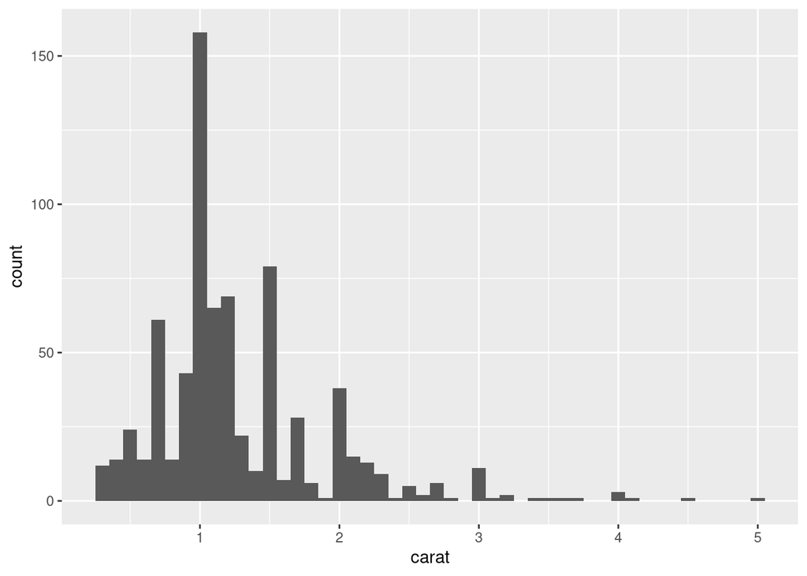

```r
carat_histogram <- function(df) {
  ggplot(df, aes(x = carat)) +
    geom_histogram(binwidth = 0.1)
}

carat_histogram(by_clarity$data[[1]])
```

Now we can use `map()` to create a list of many plots and their eventual filepaths:

```r
by_clarity <- by_clarity |>
  mutate(
    plot = map(data, carat_histogram),
    path = str_glue("clarity-{clarity}.png")
  )

by_clarity
```

```
## # A tibble: 8 × 4
##   clarity               data path             plot
##   <ord>   <list<tibble[,9]>> <glue>           <list>
## 1 I1               [741 × 9] clarity-I1.png   <gg>
## 2 SI2            [9,194 × 9] clarity-SI2.png  <gg>
## 3 SI1           [13,065 × 9] clarity-SI1.png  <gg>
## 4 VS2           [12,258 × 9] clarity-VS2.png  <gg>
## 5 VS1            [8,171 × 9] clarity-VS1.png  <gg>
## 6 VVS2           [5,066 × 9] clarity-VVS2.png <gg>
## 7 VVS1           [3,655 × 9] clarity-VVS1.png <gg>
## 8 IF             [1,790 × 9] clarity-IF.png   <gg>
```

Finally, we can use `walk2()` again, this time, with `ggsave()` to save each plot:

```r
walk2(
  by_clarity$path,
  by_clarity$plot,
  \(path, plot) ggsave(path, plot, width = 6, height = 6)
)
```